# cp2021-F06-Q05

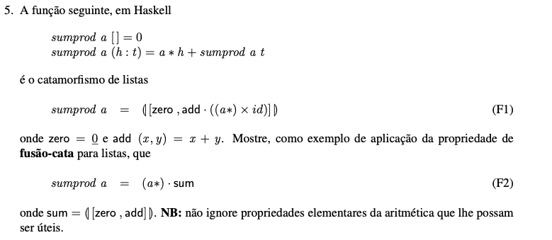

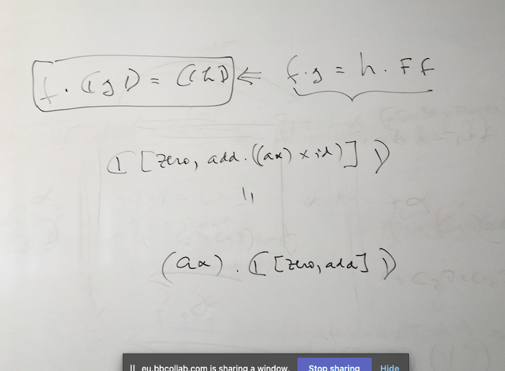

### Resolução

$\def\cata#1{\mathopen{(\!|}#1\mathclose{|\!)}}\def\kons#1{\underline{#1}}$ Mostrar que $sumprod \ a = (a*) . sum$ é o mesmo que mostrar que $\cata{[zero, add . ((a*) \times id)]} = (a*) . \cata{[zero, add]}$.

Ora, pela propriedade **fusão-cata, lei (48)** e considerando

$f = (a*)$; $g = [zero, add]$ e $h = [zero, add . ((a*) \times id)]$; $\mathbb{F} f = id + id \times f$

se conseguirmos mostrar que $f . g = h . \mathbb{F} f$ então concluimos que $f. \cata{g} = \cata{h}$.

Vamos então mostrar que

$f . g = h . \mathbb{F} f$

{ def. $f, g, h$ e $\mathbb{F} f$ }

$\equiv (a*) . [zero, add] = [zero, add . ((a*) \times id)] . (id + id \times (a*))$

{ fusão-$+$ (lei 20), absorção-$+$ (lei 22), natural-id (lei 1) }

$\equiv [(a*) . zero, (a*) . add] = [zero, add . ((a*) \times id) . (id \times (a*))]$

{ functor-$+$ (lei 25), natural-id (lei 1) }

$\equiv [(a*) . zero, (a*) . add] = [zero, add . ((a*) \times (a*))]$

{ eq-$+$ (lei 27) }

$(a*) . zero = zero$

$(a*) . add = add . ((a*) \times (a*))$

{ def. zero, igualdade extensional (lei 71), def-comp (lei 72) }

$((a*) . \kons{0}) \ x = \kons{0} \ x$

$((a*) . add) \ (x,y) = (add . ((a*) \times (a*))) \ (x,y)$

{ natural-const (lei 3); def-comp (lei 72); def-$\times$ (lei 77) }

$(a*) (0) = 0$

$(a*) (add \ (x,y)) = add ((a*) \ x, (a*) \ y)$

{ def. (a*); def. add }

$ a * 0 = 0$

$(a*) (x + y) = add (a * x, a * y)$

{ def. (a*); def. add; 0 elemento absorvente da multiplicação; prop. distributiva }

$ a * 0 = 0$

$a * (x + y) = (a * x) + (a * y)$

{ 0 elemento absorvente da multiplicação; prop. distributiva da multiplicação em relação à soma }

True

True